# M3TimeSeriesAssignment

```python
import pandas as pd
import matplotlib.pyplot as plt
import numpy as np
%matplotlib inline
```

Load the data.

```python
df = pd.read_csv('C:/Users/dirke/Downloads/CBTA Course Files/CTBA/M3/ConstructionTimeSeriesDataV2.csv')
df.head()
```

|  | Month | Month-Year | Total Construction | Private Construction | Public Construction |
| --- | --- | --- | --- | --- | --- |
| 0 | 1 | Jan-02 | 59516 | 45273 | 14243 |
| 1 | 2 | Feb-02 | 58588 | 44475 | 14113 |
| 2 | 3 | Mar-02 | 63782 | 49396 | 14386 |
| 3 | 4 | Apr-02 | 69504 | 53283 | 16221 |
| 4 | 5 | May-02 | 73384 | 55009 | 18375 |

# Private Construction Spending Data Analysis

Visualize the Private Construction data.

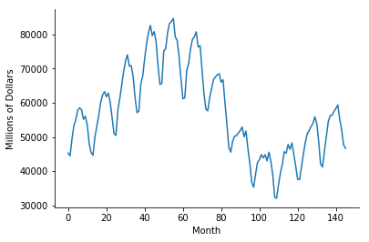

```python
fig,ax = plt.subplots()
ax.plot(df['Private Construction'],label='Private Construction')
ax.set_xlabel('Month')
ax.set_ylabel('Millions of Dollars')
ax.spines['right'].set_visible(False)
ax.spines['top'].set_visible(False)
```

The moving average, squared error, and average squared error are then computed.

```
Average Squared Error per Month:  37395667.05489795
            Month Month-Year  Total Construction  Private Construction  \
2009-02-28     19     Jul-03               82971                 62216
2009-03-31     20     Aug-03               85191                 63234
2009-04-30     21     Sep-03               83841                 61767
2009-05-31     22     Oct-03               83133                 62813
2009-06-30     23     Nov-03               77915                 60115
2009-07-31     24     Dec-03               71050                 55584
2009-08-31     25     Jan-04               64934                 50975
2009-09-30     26     Feb-04               64138                 50449
2009-10-31     27     Mar-04               73238                 57796
2009-11-30     28     Apr-04               78354                 61177
2009-12-31     29     May-04               83736                 65027
2010-01-31     30     Jun-04               89932                 69039
2010-02-28     31     Jul-04               93614                 72170
2010-03-31     32     Aug-04               96164                 74001
2010-04-30     33     Sep-04               92538                 70662
2010-05-31     34     Oct-04               90582                 70856
2010-06-30     35     Nov-04               86394                 67585
2010-07-31     36     Dec-04               77733                 61438
2010-08-31     37     Jan-05               71474                 57094
2010-09-30     38     Feb-05               72048                 57531
2010-10-31     39     Mar-05               81345                 65425
2010-11-30     40     Apr-05               85485                 67829
2010-12-31     41     May-05               92959                 72862
2011-01-31     42     Jun-05               99632                 77258
2011-02-28     43     Jul-05              103158                 80480
2011-03-31     44     Aug-05              106706                 82629
2011-04-30     45     Sep-05              103269                 79584
2011-05-31     46     Oct-05              102339                 80820
2011-06-30     47     Nov-05               97549                 77774
2011-07-31     48     Dec-05               88172                 70692
...           ...        ...                 ...                   ...
2015-10-31     99     Mar-10               60228                 39090
2015-11-30    100     Apr-10               66422                 42486
2015-12-31    101     May-10               68906                 43340
2016-01-31    102     Jun-10               74035                 44831
2016-02-29    103     Jul-10               73077                 43851
2016-03-31    104     Aug-10               75834                 44803
2016-04-30    105     Sep-10               74764                 42978
```

[output cut: 73 more lines]

```
2017-03-31                29297  44125.541667  1.355314e+07
2017-04-30                28990  44300.791667  4.331428e+06
2017-05-31                25957  44498.361111  1.419510e+07
2017-06-30                24014  44756.208333  1.504793e+03
2017-07-31                20828  45067.680556  1.334938e+07
2017-08-31                18059  45399.625000  6.066268e+07
2017-09-30                18483  45749.361111  6.808496e+07
2017-10-31                19491  46138.208333  2.336957e+07
2017-11-30                21259  46543.069444  2.493460e+06
2017-12-31                23898  46907.194444  2.058667e+06
2018-01-31                26975  47262.611111  1.323060e+07
2018-02-28                27104  47660.583333  1.708513e+07
2018-03-31                28640  48077.638889  2.495363e+07

[110 rows x 7 columns]
```

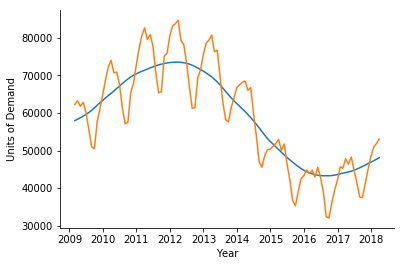

```python
def sqErr(row):
    return (row['Private Construction'] - row['MovAvg'])**2

df['MovAvg'] = np.NaN
df['sqErr'] = np.NaN
# Chaging the DataFrame index to DatetimeIndex data type is required for using one of the functions below
df.index = pd.DatetimeIndex(freq='m', start=pd.Timestamp(year=2007, month=8, day=31), periods = len(df['Private Construction']))
#print(len(data),'\n',data)

window = 36
window = window - window % 2
# Compute the moving average in the loop below using a window centered on the data point whose average is eing computed
for i in range(int(window/2),df.shape[0]-int(window/2)):
    df.loc[df.index[i],'MovAvg'] = (0.5*df.iloc[i - int(window/2)]['Private Construction'] + df.iloc[i - int(window/2)+1:i + int(window/2)]['Private Construction'].sum() + 0.5*df.iloc[i + int(window/2)]['Private Construction'])/float(window)

df['sqErr'] = (df['Private Construction'] - df['MovAvg'])**2
# The squared error can eb computed also with the dfHA.apply() method below
# Using dfHS.apply() in this case is unecessary complexity, but it is a good function to know about
#dfHS['sqErr'] = dfHS.apply(sqErr,axis='columns')

# The moving average cannot be applied to all rows and we need to delete those rows because we cannot use them in the analysis
df.dropna(how='any',inplace=True)
df.head()

fig,ax = plt.subplots()
ax.plot(df['MovAvg'],label='Moving Avg.')
ax.plot(df['Private Construction'],label='Private Construction Spending')
ax.set_xlabel('Year')
ax.set_ylabel('Units of Demand')
ax.spines['right'].set_visible(False)
ax.spines['top'].set_visible(False)
print('Average Squared Error per Month: ',sum(df['sqErr'])/len(df))
print(df)
```

The residual Private Construction spending yet to be explained, 𝑅1 , is computed by subtracting the moving average from the time series.

```python
df['R1'] = df['Private Construction'] - df['MovAvg']
df['R1Error'] = abs((df['Private Construction'] - df['R1'])/df['Private Construction'])
df.style.format({
    'MovAvg': '{:.1f}'.format,
    'sqErr': '{:,.1f}'.format,
    'R1': '{:,.1f}'.format,
    'R1Error': '{:,.3f}'.format
})
```

|  | Month | Month-Year | Total Construction | Private Construction | Public Construction | MovAvg | sqErr | R1 | R1Error |
| --- | --- | --- | --- | --- | --- | --- | --- | --- | --- |
| 2009-02-28 00:00:00 | 19 | Jul-03 | 82971 | 62216 | 20755 | 57969.4 | 18,033,352.0 | 4,246.6 | 0.932 |
| 2009-03-31 00:00:00 | 20 | Aug-03 | 85191 | 63234 | 21957 | 58314.9 | 24,197,107.6 | 4,919.1 | 0.922 |
| 2009-04-30 00:00:00 | 21 | Sep-03 | 83841 | 61767 | 22075 | 58718.9 | 9,290,896.7 | 3,048.1 | 0.951 |
| 2009-05-31 00:00:00 | 22 | Oct-03 | 83133 | 62813 | 20321 | 59143.6 | 13,464,822.5 | 3,669.4 | 0.942 |
| 2009-06-30 00:00:00 | 23 | Nov-03 | 77915 | 60115 | 17801 | 59593.5 | 271,918.8 | 521.5 | 0.991 |
| 2009-07-31 00:00:00 | 24 | Dec-03 | 71050 | 55584 | 15466 | 60111.7 | 20,500,394.3 | -4,527.7 | 1.081 |
| 2009-08-31 00:00:00 | 25 | Jan-04 | 64934 | 50975 | 13959 | 60687.3 | 94,329,418.8 | -9,712.3 | 1.191 |
| 2009-09-30 00:00:00 | 26 | Feb-04 | 64138 | 50449 | 13689 | 61335.4 | 118,514,067.8 | -10,886.4 | 1.216 |
| 2009-10-31 00:00:00 | 27 | Mar-04 | 73238 | 57796 | 15443 | 62017.4 | 17,820,241.4 | -4,221.4 | 1.073 |
| 2009-11-30 00:00:00 | 28 | Apr-04 | 78354 | 61177 | 17177 | 62701.1 | 2,322,787.7 | -1,524.1 | 1.025 |
| 2009-12-31 00:00:00 | 29 | May-04 | 83736 | 65027 | 18709 | 63381.9 | 2,706,390.6 | 1,645.1 | 0.975 |
| 2010-01-31 00:00:00 | 30 | Jun-04 | 89932 | 69039 | 20893 | 64033.2 | 25,058,506.4 | 5,005.8 | 0.927 |
| 2010-02-28 00:00:00 | 31 | Jul-04 | 93614 | 72170 | 21444 | 64623.9 | 56,943,373.7 | 7,546.1 | 0.895 |
| 2010-03-31 00:00:00 | 32 | Aug-04 | 96164 | 74001 | 22164 | 65191.5 | 77,606,800.8 | 8,809.5 | 0.881 |
| 2010-04-30 00:00:00 | 33 | Sep-04 | 92538 | 70662 | 21876 | 65832.8 | 23,321,521.4 | 4,829.2 | 0.932 |
| 2010-05-31 00:00:00 | 34 | Oct-04 | 90582 | 70856 | 19726 | 66496.0 | 19,009,721.1 | 4,360.0 | 0.938 |
| 2010-06-30 00:00:00 | 35 | Nov-04 | 86394 | 67585 | 18809 | 67145.8 | 192,891.8 | 439.2 | 0.994 |
| 2010-07-31 00:00:00 | 36 | Dec-04 | 77733 | 61438 | 16295 | 67803.1 | 40,513,932.2 | -6,365.1 | 1.104 |
| 2010-08-31 00:00:00 | 37 | Jan-05 | 71474 | 57094 | 14380 | 68422.6 | 128,336,171.0 | -11,328.6 | 1.198 |
| 2010-09-30 00:00:00 | 38 | Feb-05 | 72048 | 57531 | 14517 | 69018.4 | 131,959,784.4 | -11,487.4 | 1.200 |
| 2010-10-31 00:00:00 | 39 | Mar-05 | 81345 | 65425 | 15920 | 69558.9 | 17,088,922.5 | -4,133.9 | 1.063 |
| 2010-11-30 00:00:00 | 40 | Apr-05 | 85485 | 67829 | 17656 | 70015.6 | 4,781,389.6 | -2,186.6 | 1.032 |
| 2010-12-31 00:00:00 | 41 | May-05 | 92959 | 72862 | 20097 | 70414.7 | 5,989,304.5 | 2,447.3 | 0.966 |
| 2011-01-31 00:00:00 | 42 | Jun-05 | 99632 | 77258 | 22375 | 70758.2 | 42,247,111.2 | 6,499.8 | 0.916 |
| 2011-02-28 00:00:00 | 43 | Jul-05 | 103158 | 80480 | 22679 | 71057.9 | 88,776,701.2 | 9,422.1 | 0.883 |
| 2011-03-31 00:00:00 | 44 | Aug-05 | 106706 | 82629 | 24078 | 71351.9 | 127,171,982.0 | 11,277.1 | 0.864 |
| 2011-04-30 00:00:00 | 45 | Sep-05 | 103269 | 79584 | 23685 | 71665.8 | 62,698,463.1 | 7,918.2 | 0.901 |
| 2011-05-31 00:00:00 | 46 | Oct-05 | 102339 | 80820 | 21519 | 71969.4 | 78,332,825.3 | 8,850.6 | 0.890 |
| 2011-06-30 00:00:00 | 47 | Nov-05 | 97549 | 77774 | 19775 | 72259.9 | 30,405,421.3 | 5,514.1 | 0.929 |
| 2011-07-31 00:00:00 | 48 | Dec-05 | 88172 | 70692 | 17479 | 72540.2 | 3,415,771.4 | -1,848.2 | 1.026 |

[output cut: 80 more lines]

The cell below helps to visualize the remaining pattern to be decomposed, 𝑅1 , and it also computes the average residual demand pattern.

```
Average Residual:  113.25315656565621
```

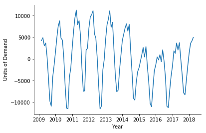

```python
fig,ax = plt.subplots()
ax.plot(df['R1'])
ax.set_xlabel('Year')
ax.set_ylabel('Units of Demand')
ax.spines['right'].set_visible(False)
ax.spines['top'].set_visible(False)
print('Average Residual: ', sum(df['R1'])/len(df))
```

Autocorrelation analysis is used to detect whether any cyclical patterns exist and how many periods before they are repeated. As can be seen in the output below, the maximum correlation appears in period 12 indicating a 12 month cyclical pattern is strongest.

```python
maxCorr = 0.0
period = np.NaN
for i in range(1,37):
    corr = df['R1'].autocorr(lag=i)
    print('Correlation, lag ',i,'   ',corr)
    if corr > maxCorr:
        maxCorr = corr
        period = i
print('period = ',period,'     Maximum Correlation = ',maxCorr)
```

```
Correlation, lag  1     0.8250475036301713
Correlation, lag  2     0.4820939752221447
Correlation, lag  3     0.0661838628463355
Correlation, lag  4     -0.29310582259154694
Correlation, lag  5     -0.5386625150984725
Correlation, lag  6     -0.6496282831082484
Correlation, lag  7     -0.549838477475518
Correlation, lag  8     -0.3185413831731613
Correlation, lag  9     0.02011606382325631
Correlation, lag  10     0.41176952584284515
Correlation, lag  11     0.7322731003955263
Correlation, lag  12     0.8944851710984221
Correlation, lag  13     0.7299213692607464
Correlation, lag  14     0.4055214152186815
Correlation, lag  15     0.0031237974667481893
Correlation, lag  16     -0.34159925855108353
Correlation, lag  17     -0.5745510163732713
Correlation, lag  18     -0.681216824190257
Correlation, lag  19     -0.5902172854543253
Correlation, lag  20     -0.37531995989940625
Correlation, lag  21     -0.04750388422754723
Correlation, lag  22     0.3369494305895757
Correlation, lag  23     0.6572135458224128
Correlation, lag  24     0.8250377247910974
Correlation, lag  25     0.6796473144842703
Correlation, lag  26     0.3697716757524485
Correlation, lag  27     -0.031763738440921285
Correlation, lag  28     -0.3864486695652997
Correlation, lag  29     -0.629267851757631
Correlation, lag  30     -0.7352864412725051
Correlation, lag  31     -0.6386019116542909
Correlation, lag  32     -0.42297520217029344
Correlation, lag  33     -0.09831675443648784
Correlation, lag  34     0.281952534008814
Correlation, lag  35     0.6041349156276149
Correlation, lag  36     0.786554093702412
period =  12      Maximum Correlation =  0.8944851710984221
```

The following block of code plots each 12 month cycle, as well as an average of all the cycles.

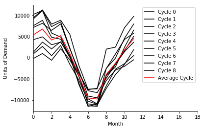

```python
period = 12
cycleLen = period
numCycles = int(len(df)/cycleLen + 0.5)
cycles = [df.iloc[range(i*period,min((i+1)*period,len(df)))]['R1'] for i in range(numCycles)]
ptsInCycles = [df.iloc[range(i,len(df['R1']),period)]['R1'].tolist() for i in range(period)]
avg = [sum(pts)/len(pts) for pts in ptsInCycles]

fig,ax = plt.subplots()
for i in range(len(cycles)):
    ax.plot(cycles[i].values,label='Cycle '+str(i),c='k')
ax.plot(avg,label='Average Cycle',c='r')
ax.set_xlabel('Month')
ax.set_ylabel('Units of Demand')
ax.spines['right'].set_visible(False)
ax.spines['top'].set_visible(False)
ax.set_xlim(0,18)
ax.legend()
```

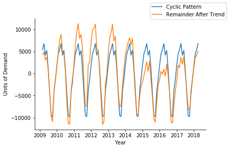

```python
cycleLen = period   # see prior cell for computation of cyclicality period
numCycles = int(len(df)/cycleLen + 0.5)
df['C'] = np.NaN   # Creates an empty column for the cyclicality component data
for i in range(len(df)):
    df.loc[df.index[i], 'C'] = avg[i % cycleLen] # Write appropriate cyclicality value

fig,ax = plt.subplots()
ax.plot(df['C'],label='Cyclic Pattern')
ax.plot(df['R1'],label='Remainder After Trend')
ax.set_xlabel('Year')
ax.set_ylabel('Units of Demand')
ax.spines['right'].set_visible(False)
ax.spines['top'].set_visible(False)
fig.legend()
```

The code cell below does these:

- Computes the remaining residual private construction spending to be explained, R2Private , after subtracting the cyclical component, 𝐶(𝑚) : this is the 𝜖(𝑚) in the model.
- Computes the error, R2ErrorPrivate , as a percentage of the time series.
- Computes the mathematical model 'fit', composed of the trend and cyclical components: 𝑇(𝑚)+𝐶(𝑚) .
- Plots the fit of the model 𝑇(𝑚)+𝐶(𝑚) with the original data, 𝐻(𝑚) .
- Computes the average absolute error of R2ErrorPrivate of the original time series.
- Removes the sqErr column because it is no longer needed

```
Average Error:  0.037815969902102356
            Month Month-Year  Total Construction  Private Construction  \
2009-02-28     19     Jul-03               82971                 62216
2009-03-31     20     Aug-03               85191                 63234
2009-04-30     21     Sep-03               83841                 61767
2009-05-31     22     Oct-03               83133                 62813
2009-06-30     23     Nov-03               77915                 60115
2009-07-31     24     Dec-03               71050                 55584
2009-08-31     25     Jan-04               64934                 50975
2009-09-30     26     Feb-04               64138                 50449
2009-10-31     27     Mar-04               73238                 57796
2009-11-30     28     Apr-04               78354                 61177
2009-12-31     29     May-04               83736                 65027
2010-01-31     30     Jun-04               89932                 69039
2010-02-28     31     Jul-04               93614                 72170
2010-03-31     32     Aug-04               96164                 74001
2010-04-30     33     Sep-04               92538                 70662
2010-05-31     34     Oct-04               90582                 70856
2010-06-30     35     Nov-04               86394                 67585
2010-07-31     36     Dec-04               77733                 61438
2010-08-31     37     Jan-05               71474                 57094
2010-09-30     38     Feb-05               72048                 57531
2010-10-31     39     Mar-05               81345                 65425
2010-11-30     40     Apr-05               85485                 67829
2010-12-31     41     May-05               92959                 72862
2011-01-31     42     Jun-05               99632                 77258
2011-02-28     43     Jul-05              103158                 80480
2011-03-31     44     Aug-05              106706                 82629
2011-04-30     45     Sep-05              103269                 79584
2011-05-31     46     Oct-05              102339                 80820
2011-06-30     47     Nov-05               97549                 77774
2011-07-31     48     Dec-05               88172                 70692
...           ...        ...                 ...                   ...
2015-10-31     99     Mar-10               60228                 39090
2015-11-30    100     Apr-10               66422                 42486
2015-12-31    101     May-10               68906                 43340
2016-01-31    102     Jun-10               74035                 44831
2016-02-29    103     Jul-10               73077                 43851
2016-03-31    104     Aug-10               75834                 44803
2016-04-30    105     Sep-10               74764                 42978
```

[output cut: 136 more lines]

```
2017-03-31  6774.126389 -3092.668056        0.064691  50899.668056
2017-04-30  4146.766975 -2065.558642        0.044534  48447.558642
2017-05-31  5216.117284 -1448.478395        0.030010  49714.478395
2017-06-30  1011.337963  -972.546296        0.021711  45767.546296
2017-07-31 -4325.425926   671.745370        0.016220  40742.254630
2017-08-31 -9504.104938  1715.479938        0.045611  35895.520062
2017-09-30 -9748.245370  1496.884259        0.039919  36001.115741
2017-10-31 -3945.387346  -888.820988        0.021519  42192.820988
2017-11-30 -1303.533951  -275.535494        0.006128  45239.535494
2017-12-31  1834.348765  -399.543210        0.008265  48741.543210
2018-01-31  4496.526235  -859.137346        0.016879  51759.137346
2018-02-28  5381.098611 -1247.681944        0.024089  53041.681944
2018-03-31  6774.126389 -1778.765278        0.033515  54851.765278

[110 rows x 12 columns]
```

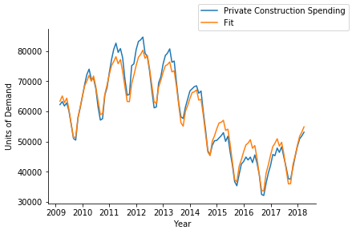

```python
df['R2Private'] = df['R1'] - df['C']
df['R2ErrorPrivate'] = abs(df['R2Private']/df['Private Construction'])
df['fit'] = df['MovAvg'] + df['C']
df.drop(['sqErr'],axis=1,inplace=True)
print('Average Error: ', sum(df['R2ErrorPrivate'])/len(df))
print(df)
fig,ax = plt.subplots()
ax.plot(df['Private Construction'],label='Private Construction Spending')
ax.plot(df['fit'], label = 'Fit')
ax.set_xlabel('Year')
ax.set_ylabel('Units of Demand')
ax.spines['right'].set_visible(False)
ax.spines['top'].set_visible(False)
fig.legend()
```

# Public Construction Spending Data Analysis

Visualize the Public Construction data.

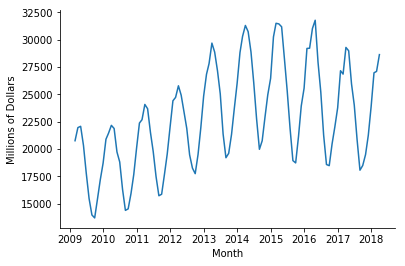

```python
fig,ax = plt.subplots()
ax.plot(df['Public Construction'],label='Public Construction')
ax.set_xlabel('Month')
ax.set_ylabel('Millions of Dollars')
ax.spines['right'].set_visible(False)
ax.spines['top'].set_visible(False)
```

The moving average, squared error, and average squared error are then computed.

```
Average Squared Error per Month:  14980631.752288744
            Month Month-Year  Total Construction  Private Construction  \
2009-02-28     37     Jan-05               71474                 57094
2009-03-31     38     Feb-05               72048                 57531
2009-04-30     39     Mar-05               81345                 65425
2009-05-31     40     Apr-05               85485                 67829
2009-06-30     41     May-05               92959                 72862
2009-07-31     42     Jun-05               99632                 77258
2009-08-31     43     Jul-05              103158                 80480
2009-09-30     44     Aug-05              106706                 82629
2009-10-31     45     Sep-05              103269                 79584
2009-11-30     46     Oct-05              102339                 80820
2009-12-31     47     Nov-05               97549                 77774
2010-01-31     48     Dec-05               88172                 70692
2010-02-28     49     Jan-06               81058                 65339
2010-03-31     50     Feb-06               81478                 65622
2010-04-30     51     Mar-06               92855                 75163
2010-05-31     52     Apr-06               95324                 75780
2010-06-30     53     May-06              102495                 80488
2010-07-31     54     Jun-06              107607                 83196
2010-08-31     55     Jul-06              108423                 83700
2010-09-30     56     Aug-06              110434                 84649
2010-10-31     57     Sep-06              104191                 79268
2010-11-30     58     Oct-06              101582                 78199
2010-12-31     59     Nov-06               95339                 73461
2011-01-31     60     Dec-06               86436                 66972
2011-02-28     61     Jan-07               79406                 61161
2011-03-31     62     Feb-07               79177                 61437
2011-04-30     63     Mar-07               88905                 69403
2011-05-31     64     Apr-07               93375                 71433
2011-06-30     65     May-07              100534                 75685
2011-07-31     66     Jun-07              105399                 78562
...           ...        ...                 ...                   ...
2012-10-31     81     Sep-08               96755                 66012
2012-11-30     82     Oct-08               95612                 66730
2012-12-31     83     Nov-08               86067                 59993
2013-01-31     84     Dec-08               76645                 53884
2013-02-28     85     Jan-09               66944                 46974
2013-03-31     86     Feb-09               66296                 45548
2013-04-30     87     Mar-09               71624                 48688
```

[output cut: 199 more lines]

```
2014-03-31  4.477208e+07
2014-04-30  1.784980e+07
2014-05-31  1.854817e+06
2014-06-30  1.144600e+05
2014-07-31  1.624706e+07
2014-08-31  1.686060e+07
2014-09-30  3.563112e+07
2014-10-31  4.628742e+07
2014-11-30  9.288103e+06
2014-12-31  1.752353e+05
2015-01-31  1.184125e+07
2015-02-28  3.636509e+07
2015-03-31  3.639910e+07

[74 rows x 13 columns]
```

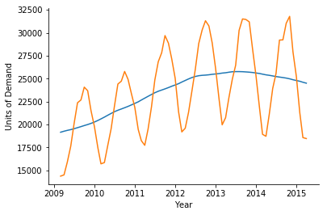

```python
def sqErr(row):
    return (row['Public Construction'] - row['MovAvg'])**2

df['MovAvg'] = np.NaN
df['sqErr'] = np.NaN
# Chaging the DataFrame index to DatetimeIndex data type is required for using one of the functions below
df.index = pd.DatetimeIndex(freq='m', start=pd.Timestamp(year=2007, month=8, day=31), periods = len(df['Public Construction']))
#print(len(data),'\n',data)

window = 36
window = window - window % 2
# Compute the moving average in the loop below using a window centered on the data point whose average is eing computed
for i in range(int(window/2),df.shape[0]-int(window/2)):
    df.loc[df.index[i],'MovAvg'] = (0.5*df.iloc[i - int(window/2)]['Public Construction'] + df.iloc[i - int(window/2)+1:i + int(window/2)]['Public Construction'].sum() + 0.5*df.iloc[i + int(window/2)]['Public Construction'])/float(window)

df['sqErr'] = (df['Public Construction'] - df['MovAvg'])**2
# The squared error can eb computed also with the dfHA.apply() method below
# Using dfHS.apply() in this case is unecessary complexity, but it is a good function to know about
#dfHS['sqErr'] = dfHS.apply(sqErr,axis='columns')

# The moving average cannot be applied to all rows and we need to delete those rows because we cannot use them in the analysis
df.dropna(how='any',inplace=True)
df.head()

fig,ax = plt.subplots()
ax.plot(df['MovAvg'],label='Moving Avg.')
ax.plot(df['Public Construction'],label='Public Construction Spending')
ax.set_xlabel('Year')
ax.set_ylabel('Units of Demand')
ax.spines['right'].set_visible(False)
ax.spines['top'].set_visible(False)
print('Average Squared Error per Month: ',sum(df['sqErr'])/len(df))
print(df)
```

The residual Public Construction spending yet to be explained, 𝑅1 , is computed by subtracting the moving average from the time series.

```python
df['R1'] = df['Public Construction'] - df['MovAvg']
df['R1Error'] = abs((df['Public Construction'] - df['R1'])/df['Public Construction'])
df.style.format({
    'MovAvg': '{:.1f}'.format,
    'sqErr': '{:,.1f}'.format,
    'R1': '{:,.1f}'.format,
    'R1Error': '{:,.3f}'.format
})
```

|  | Month | Month-Year | Total Construction | Private Construction | Public Construction | MovAvg | R1 | R1Error | C | R2Private | R2ErrorPrivate | fit | sqErr |
| --- | --- | --- | --- | --- | --- | --- | --- | --- | --- | --- | --- | --- | --- |
| 2009-02-28 00:00:00 | 37 | Jan-05 | 71474 | 57094 | 14380 | 19164.8 | -4,784.8 | 1.333 | -9504.1 | -1824.45 | 0.0319552 | 58918.5 | 22,894,364.2 |
| 2009-03-31 00:00:00 | 38 | Feb-05 | 72048 | 57531 | 14517 | 19273.1 | -4,756.1 | 1.328 | -9748.25 | -1739.13 | 0.0302294 | 59270.1 | 22,620,328.7 |
| 2009-04-30 00:00:00 | 39 | Mar-05 | 81345 | 65425 | 15920 | 19365.8 | -3,445.8 | 1.216 | -3945.39 | -188.488 | 0.00288097 | 65613.5 | 11,873,575.9 |
| 2009-05-31 00:00:00 | 40 | Apr-05 | 85485 | 67829 | 17656 | 19447.9 | -1,791.9 | 1.101 | -1303.53 | -883.105 | 0.0130196 | 68712.1 | 3,210,915.6 |
| 2009-06-30 00:00:00 | 41 | May-05 | 92959 | 72862 | 20097 | 19547.1 | 549.9 | 0.973 | 1834.35 | 612.957 | 0.00841257 | 72249 | 302,423.6 |
| 2009-07-31 00:00:00 | 42 | Jun-05 | 99632 | 77258 | 22375 | 19659.2 | 2,715.8 | 0.879 | 4496.53 | 2003.25 | 0.0259294 | 75254.7 | 7,375,448.9 |
| 2009-08-31 00:00:00 | 43 | Jul-05 | 103158 | 80480 | 22679 | 19774.3 | 2,904.7 | 0.872 | 5381.1 | 4041.04 | 0.0502117 | 76439 | 8,437,411.2 |
| 2009-09-30 00:00:00 | 44 | Aug-05 | 106706 | 82629 | 24078 | 19890.1 | 4,187.9 | 0.826 | 6774.13 | 4502.93 | 0.0544957 | 78126.1 | 17,538,762.3 |
| 2009-10-31 00:00:00 | 45 | Sep-05 | 103269 | 79584 | 23685 | 20002.7 | 3,682.3 | 0.845 | 4146.77 | 3771.47 | 0.0473898 | 75812.5 | 13,559,169.6 |
| 2009-11-30 00:00:00 | 46 | Oct-05 | 102339 | 80820 | 21519 | 20125.3 | 1,393.7 | 0.935 | 5216.12 | 3634.47 | 0.0449699 | 77185.5 | 1,942,422.9 |
| 2009-12-31 00:00:00 | 47 | Nov-05 | 97549 | 77774 | 19775 | 20276.8 | -501.8 | 1.025 | 1011.34 | 4502.77 | 0.0578956 | 73271.2 | 251,753.1 |
| 2010-01-31 00:00:00 | 48 | Dec-05 | 88172 | 70692 | 17479 | 20444.6 | -2,965.6 | 1.170 | -4325.43 | 2477.25 | 0.0350428 | 68214.8 | 8,794,684.5 |
| 2010-02-28 00:00:00 | 49 | Jan-06 | 81058 | 65339 | 15719 | 20615.7 | -4,896.7 | 1.312 | -9504.1 | 2072.05 | 0.0317123 | 63267 | 23,977,616.5 |
| 2010-03-31 00:00:00 | 50 | Feb-06 | 81478 | 65622 | 15857 | 20808.8 | -4,951.8 | 1.312 | -9748.25 | 2407.02 | 0.0366801 | 63215 | 24,520,515.8 |
| 2010-04-30 00:00:00 | 51 | Mar-06 | 92855 | 75163 | 17692 | 21010.5 | -3,318.5 | 1.188 | -3945.39 | 5973.61 | 0.0794754 | 69189.4 | 11,012,718.8 |
| 2010-05-31 00:00:00 | 52 | Apr-06 | 95324 | 75780 | 19544 | 21210.8 | -1,666.8 | 1.085 | -1303.53 | 3789.66 | 0.0500087 | 71990.3 | 2,778,333.4 |
| 2010-06-30 00:00:00 | 53 | May-06 | 102495 | 80488 | 22007 | 21400.6 | 606.4 | 0.972 | 1834.35 | 5248.23 | 0.0652052 | 75239.8 | 367,741.2 |
| 2010-07-31 00:00:00 | 54 | Jun-06 | 107607 | 83196 | 24411 | 21557.8 | 2,853.2 | 0.883 | 4496.53 | 5244.14 | 0.0630336 | 77951.9 | 8,140,877.0 |
| 2010-08-31 00:00:00 | 55 | Jul-06 | 108423 | 83700 | 24723 | 21695.3 | 3,027.7 | 0.878 | 5381.1 | 4829.43 | 0.0576993 | 78870.6 | 9,167,017.8 |
| 2010-09-30 00:00:00 | 56 | Aug-06 | 110434 | 84649 | 25785 | 21832.8 | 3,952.2 | 0.847 | 6774.13 | 4369.43 | 0.0516182 | 80279.6 | 15,619,511.6 |
| 2010-10-31 00:00:00 | 57 | Sep-06 | 104191 | 79268 | 24923 | 21978.7 | 2,944.3 | 0.882 | 4146.77 | 1669.8 | 0.0210653 | 77598.2 | 8,668,935.2 |
| 2010-11-30 00:00:00 | 58 | Oct-06 | 101582 | 78199 | 23384 | 22137.8 | 1,246.2 | 0.947 | 5216.12 | -360.756 | 0.00461331 | 78559.8 | 1,553,139.1 |
| 2010-12-31 00:00:00 | 59 | Nov-06 | 95339 | 73461 | 21878 | 22303.8 | -425.8 | 1.019 | 1011.34 | -756.852 | 0.0103028 | 74217.9 | 181,274.9 |
| 2011-01-31 00:00:00 | 60 | Dec-06 | 86436 | 66972 | 19464 | 22475.5 | -3,011.5 | 1.155 | -4325.43 | -1689.12 | 0.0252212 | 68661.1 | 9,069,132.2 |
| 2011-02-28 00:00:00 | 61 | Jan-07 | 79406 | 61161 | 18245 | 22670.9 | -4,425.9 | 1.243 | -9504.1 | -2015.28 | 0.0329505 | 63176.3 | 19,588,984.2 |
| 2011-03-31 00:00:00 | 62 | Feb-07 | 79177 | 61437 | 17740 | 22877.3 | -5,137.3 | 1.290 | -9748.25 | -1127.75 | 0.0183563 | 62564.8 | 26,391,480.3 |
| 2011-04-30 00:00:00 | 63 | Mar-07 | 88905 | 69403 | 19503 | 23075.7 | -3,572.7 | 1.183 | -3945.39 | 1420.44 | 0.0204666 | 67982.6 | 12,764,344.1 |
| 2011-05-31 00:00:00 | 64 | Apr-07 | 93375 | 71433 | 21942 | 23276.0 | -1,334.0 | 1.061 | -1303.53 | 1192.78 | 0.0166979 | 70240.2 | 1,779,630.1 |
| 2011-06-30 00:00:00 | 65 | May-07 | 100534 | 75685 | 24849 | 23465.8 | 1,383.2 | 0.944 | 1834.35 | 2749.55 | 0.0363289 | 72935.4 | 1,913,303.7 |
| 2011-07-31 00:00:00 | 66 | Jun-07 | 105399 | 78562 | 26837 | 23626.6 | 3,210.4 | 0.880 | 4496.53 | 3444.78 | 0.0438479 | 75117.2 | 10,306,596.8 |
| 2011-08-31 00:00:00 | 67 | Jul-07 | 107090 | 79270 | 27820 | 23759.0 | 4,061.0 | 0.854 | 5381.1 | 3756.72 | 0.0473915 | 75513.3 | 16,491,495.4 |
| 2011-09-30 00:00:00 | 68 | Aug-07 | 110430 | 80737 | 29693 | 23886.0 | 5,807.0 | 0.804 | 6774.13 | 4364.57 | 0.0540591 | 76372.4 | 33,721,087.7 |
| 2011-10-31 00:00:00 | 69 | Sep-07 | 105150 | 76278 | 28871 | 24026.8 | 4,844.2 | 0.832 | 4146.77 | 3179.44 | 0.0416823 | 73098.6 | 23,466,488.9 |
| 2011-11-30 00:00:00 | 70 | Oct-07 | 103847 | 76695 | 27152 | 24174.7 | 2,977.3 | 0.890 | 5216.12 | 3249.6 | 0.0423705 | 73445.4 | 8,864,100.3 |
| 2011-12-31 00:00:00 | 71 | Nov-07 | 94822 | 69777 | 25045 | 24311.8 | 733.2 | 0.971 | 1011.34 | 1309.88 | 0.0187724 | 68467.1 | 537,594.5 |
| 2012-01-31 00:00:00 | 72 | Dec-07 | 84218 | 62840 | 21377 | 24454.9 | -3,077.9 | 1.144 | -4325.43 | 573.148 | 0.00912075 | 62266.9 | 9,473,742.0 |
| 2012-02-29 00:00:00 | 73 | Jan-08 | 77349 | 58150 | 19199 | 24630.4 | -5,431.4 | 1.283 | -9504.1 | 1948.69 | 0.0335114 | 56201.3 | 29,499,985.3 |
| 2012-03-31 00:00:00 | 74 | Feb-08 | 77227 | 57625 | 19602 | 24803.3 | -5,201.3 | 1.265 | -9748.25 | 2550.61 | 0.0442622 | 55074.4 | 27,053,435.0 |
| 2012-04-30 00:00:00 | 75 | Mar-08 | 82779 | 61442 | 21336 | 24969.0 | -3,633.0 | 1.170 | -3945.39 | 1411.61 | 0.0229747 | 60030.4 | 13,198,588.1 |
| 2012-05-31 00:00:00 | 76 | Apr-08 | 87743 | 64051 | 23692 | 25123.2 | -1,431.2 | 1.060 | -1303.53 | 2152.53 | 0.0336066 | 61898.5 | 2,048,238.0 |
| 2012-06-30 00:00:00 | 77 | May-08 | 92781 | 66767 | 26014 | 25238.0 | 776.0 | 0.970 | 1834.35 | 2471.37 | 0.0370149 | 64295.6 | 602,219.1 |
| 2012-07-31 00:00:00 | 78 | Jun-08 | 96338 | 67515 | 28823 | 25319.3 | 3,503.7 | 0.878 | 4496.53 | 1274.21 | 0.018873 | 66240.8 | 12,275,972.1 |
| 2012-08-31 00:00:00 | 79 | Jul-08 | 98483 | 68180 | 30303 | 25362.6 | 4,940.4 | 0.837 | 5381.1 | 1739 | 0.025506 | 66441 | 24,407,854.1 |
| 2012-09-30 00:00:00 | 80 | Aug-08 | 99786 | 68477 | 31309 | 25385.8 | 5,923.2 | 0.811 | 6774.13 | 1346.48 | 0.0196633 | 67130.5 | 35,083,903.4 |
| 2012-10-31 00:00:00 | 81 | Sep-08 | 96755 | 66012 | 30743 | 25422.2 | 5,320.8 | 0.827 | 4146.77 | 2292.94 | 0.0347352 | 63719.1 | 28,310,824.0 |
| 2012-11-30 00:00:00 | 82 | Oct-08 | 95612 | 66730 | 28883 | 25472.6 | 3,410.4 | 0.882 | 5216.12 | 2764.65 | 0.0414303 | 63965.4 | 11,630,752.4 |
| 2012-12-31 00:00:00 | 83 | Nov-08 | 86067 | 59993 | 26073 | 25510.3 | 562.7 | 0.978 | 1011.34 | 1083.7 | 0.0180638 | 58909.3 | 316,656.3 |
| 2013-01-31 00:00:00 | 84 | Dec-08 | 76645 | 53884 | 22761 | 25553.1 | -2,792.1 | 1.123 | -4325.43 | 1229.19 | 0.0228118 | 52654.8 | 7,795,962.0 |
| 2013-02-28 00:00:00 | 85 | Jan-09 | 66944 | 46974 | 19971 | 25605.5 | -5,634.5 | 1.282 | -9504.1 | 458.285 | 0.00975615 | 46515.7 | 31,747,903.3 |
| 2013-03-31 00:00:00 | 86 | Feb-09 | 66296 | 45548 | 20748 | 25643.6 | -4,895.6 | 1.236 | -9748.25 | 267.44 | 0.0058716 | 45280.6 | 23,967,280.1 |
| 2013-04-30 00:00:00 | 87 | Mar-09 | 71624 | 48688 | 22936 | 25702.7 | -2,766.7 | 1.121 | -3945.39 | -1433.83 | 0.0294495 | 50121.8 | 7,654,675.0 |
| 2013-05-31 00:00:00 | 88 | Apr-09 | 75187 | 50234 | 24953 | 25754.0 | -801.0 | 1.032 | -1303.53 | -1634.47 | 0.032537 | 51868.5 | 641,623.3 |
| 2013-06-30 00:00:00 | 89 | May-09 | 76808 | 50342 | 26466 | 25767.2 | 698.8 | 0.974 | 1834.35 | -3857.02 | 0.0766163 | 54199 | 488,329.2 |
| 2013-07-31 00:00:00 | 90 | Jun-09 | 81429 | 51170 | 30259 | 25768.1 | 4,490.9 | 0.852 | 4496.53 | -4984.47 | 0.09741 | 56154.5 | 20,167,958.3 |
| 2013-08-31 00:00:00 | 91 | Jul-09 | 83379 | 51872 | 31507 | 25758.1 | 5,748.9 | 0.818 | 5381.1 | -4476.97 | 0.0863081 | 56349 | 33,050,202.5 |
| 2013-09-30 00:00:00 | 92 | Aug-09 | 84368 | 52917 | 31450 | 25733.8 | 5,716.2 | 0.818 | 6774.13 | -4112.1 | 0.0777085 | 57029.1 | 32,675,037.7 |
| 2013-10-31 00:00:00 | 93 | Sep-09 | 81213 | 50026 | 31188 | 25706.0 | 5,482.0 | 0.824 | 4146.77 | -3668.46 | 0.0733311 | 53694.5 | 30,052,476.3 |
| 2013-11-30 00:00:00 | 94 | Oct-09 | 79949 | 51729 | 28220 | 25670.5 | 2,549.5 | 0.910 | 5216.12 | -2340.67 | 0.0452488 | 54069.7 | 6,499,879.4 |
| 2013-12-31 00:00:00 | 95 | Nov-09 | 71906 | 46599 | 25308 | 25616.1 | -308.1 | 1.012 | 1011.34 | -2580.66 | 0.0553801 | 49179.7 | 94,923.9 |
| 2014-01-31 00:00:00 | 96 | Dec-09 | 64098 | 42209 | 21889 | 25562.0 | -3,673.0 | 1.168 | -4325.43 | -987.282 | 0.0233903 | 43196.3 | 13,490,622.9 |
| 2014-02-28 00:00:00 | 97 | Jan-10 | 55586 | 36650 | 18936 | 25491.0 | -6,555.0 | 1.346 | -9504.1 | -746.062 | 0.0203564 | 37396.1 | 42,968,389.2 |
| 2014-03-31 00:00:00 | 98 | Feb-10 | 54019 | 35295 | 18724 | 25415.2 | -6,691.2 | 1.357 | -9748.25 | -1251.48 | 0.0354576 | 36546.5 | 44,772,083.1 |
| 2014-04-30 00:00:00 | 99 | Mar-10 | 60228 | 39090 | 21138 | 25362.9 | -4,224.9 | 1.200 | -3945.39 | -2699.61 | 0.0690615 | 41789.6 | 17,849,803.5 |
| 2014-05-31 00:00:00 | 100 | Apr-10 | 66422 | 42486 | 23936 | 25297.9 | -1,361.9 | 1.057 | -1303.53 | -1416.38 | 0.0333376 | 43902.4 | 1,854,817.0 |
| 2014-06-30 00:00:00 | 101 | May-10 | 68906 | 43340 | 25567 | 25228.7 | 338.3 | 0.987 | 1834.35 | -3232.74 | 0.0745902 | 46572.7 | 114,460.0 |
| 2014-07-31 00:00:00 | 102 | Jun-10 | 74035 | 44831 | 29204 | 25173.2 | 4,030.8 | 0.862 | 4496.53 | -4019.64 | 0.089662 | 48850.6 | 16,247,057.5 |
| 2014-08-31 00:00:00 | 103 | Jul-10 | 73077 | 43851 | 29226 | 25119.8 | 4,106.2 | 0.860 | 5381.1 | -5580.97 | 0.127271 | 49432 | 16,860,604.7 |
| 2014-09-30 00:00:00 | 104 | Aug-10 | 75834 | 44803 | 31031 | 25061.8 | 5,969.2 | 0.808 | 6774.13 | -5780.15 | 0.129013 | 50583.2 | 35,631,116.5 |
| 2014-10-31 00:00:00 | 105 | Sep-10 | 74764 | 42978 | 31786 | 24982.5 | 6,803.5 | 0.786 | 4146.77 | -4763.43 | 0.110834 | 47741.4 | 46,287,423.3 |
| 2014-11-30 00:00:00 | 106 | Oct-10 | 73470 | 45539 | 27931 | 24883.4 | 3,047.6 | 0.891 | 5216.12 | -3096.03 | 0.0679864 | 48635 | 9,288,102.8 |
| 2014-12-31 00:00:00 | 107 | Nov-10 | 68019 | 42805 | 25215 | 24796.4 | 418.6 | 0.983 | 1011.34 | -1524.28 | 0.0356099 | 44329.3 | 175,235.3 |
| 2015-01-31 00:00:00 | 108 | Dec-10 | 60202 | 38928 | 21274 | 24715.1 | -3,441.1 | 1.162 | -4325.43 | -32.9907 | 0.000847481 | 38961 | 11,841,245.7 |
| 2015-02-28 00:00:00 | 109 | Jan-11 | 50955 | 32377 | 18578 | 24608.3 | -6,030.3 | 1.325 | -9504.1 | -1400.48 | 0.0432553 | 33777.5 | 36,365,087.6 |
| 2015-03-31 00:00:00 | 110 | Feb-11 | 50544 | 32069 | 18475 | 24508.2 | -6,033.2 | 1.327 | -9748.25 | -1465.42 | 0.0456959 | 33534.4 | 36,399,100.0 |

The cell below helps to visualize the remaining pattern to be decomposed, 𝑅1 , and it also computes the average residual demand pattern.

```
Average Residual:  26.322072072071958
```

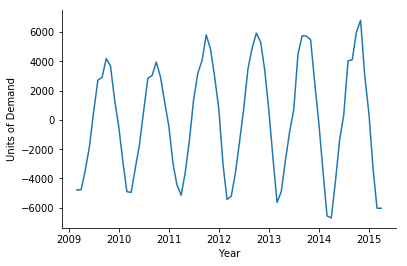

```python
fig,ax = plt.subplots()
ax.plot(df['R1'])
ax.set_xlabel('Year')
ax.set_ylabel('Units of Demand')
ax.spines['right'].set_visible(False)
ax.spines['top'].set_visible(False)
print('Average Residual: ', sum(df['R1'])/len(df))
```

Autocorrelation analysis is used to detect whether any cyclical patterns exist and how many periods before they are repeated. As can be seen in the output below, the maximum correlation appears in period 12 indicating a 12 month cyclical pattern is strongest.

```python
maxCorr = 0.0
period = np.NaN
for i in range(1,37):
    corr = df['R1'].autocorr(lag=i)
    print('Correlation, lag ',i,'   ',corr)
    if corr > maxCorr:
        maxCorr = corr
        period = i
print('period = ',period,'     Maximum Correlation = ',maxCorr)
```

```
Correlation, lag  1     0.8542129071415239
Correlation, lag  2     0.483778620982585
Correlation, lag  3     -0.014002385567195744
Correlation, lag  4     -0.49819401930502843
Correlation, lag  5     -0.829508118249748
Correlation, lag  6     -0.9523747067186772
Correlation, lag  7     -0.8405728300831049
Correlation, lag  8     -0.5008033539105848
Correlation, lag  9     -0.003965801651178323
Correlation, lag  10     0.4813005165722554
Correlation, lag  11     0.8423140416589874
Correlation, lag  12     0.9831515976360988
Correlation, lag  13     0.8538494269790771
Correlation, lag  14     0.4926720370364964
Correlation, lag  15     -0.00853743257335958
Correlation, lag  16     -0.49556326137663687
Correlation, lag  17     -0.8297630324907732
Correlation, lag  18     -0.9531763107082359
Correlation, lag  19     -0.8427618336291858
Correlation, lag  20     -0.5016993047185025
Correlation, lag  21     -0.004620756735558917
Correlation, lag  22     0.48718348876780393
Correlation, lag  23     0.8476196784556941
Correlation, lag  24     0.9811025553495574
Correlation, lag  25     0.8476228377261206
Correlation, lag  26     0.4746269009819374
Correlation, lag  27     -0.028881646948205452
Correlation, lag  28     -0.5075116510296945
Correlation, lag  29     -0.8363503398691381
Correlation, lag  30     -0.9678706445861109
Correlation, lag  31     -0.8702255897002927
Correlation, lag  32     -0.5379374122572224
Correlation, lag  33     -0.03407278765095094
Correlation, lag  34     0.48214981131327495
Correlation, lag  35     0.8454133954797538
Correlation, lag  36     0.9824773751220638
period =  12      Maximum Correlation =  0.9831515976360988
```

The following block of code plots each 12 month cycle, as well as an average of all the cycles.

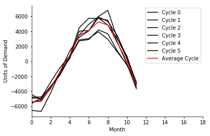

```python
period = 12
cycleLen = period
numCycles = int(len(df)/cycleLen + 0.5)
cycles = [df.iloc[range(i*period,min((i+1)*period,len(df)))]['R1'] for i in range(numCycles)]
ptsInCycles = [df.iloc[range(i,len(df['R1']),period)]['R1'].tolist() for i in range(period)]
avg = [sum(pts)/len(pts) for pts in ptsInCycles]

fig,ax = plt.subplots()
for i in range(len(cycles)):
    ax.plot(cycles[i].values,label='Cycle '+str(i),c='k')
ax.plot(avg,label='Average Cycle',c='r')
ax.set_xlabel('Month')
ax.set_ylabel('Units of Demand')
ax.spines['right'].set_visible(False)
ax.spines['top'].set_visible(False)
ax.set_xlim(0,18)
ax.legend()
```

The appropriate 𝐶(𝑚) value is inserted into the 𝐶 column in the DataFrame for each Month 𝑚. The cyclicality component 𝐶(𝑚) is then plotted with the 𝑅1 column to see how well the cyclicality component and it match. As can be seen in the graph below, the cyclicality component matches very closely with the 𝑅1 column.

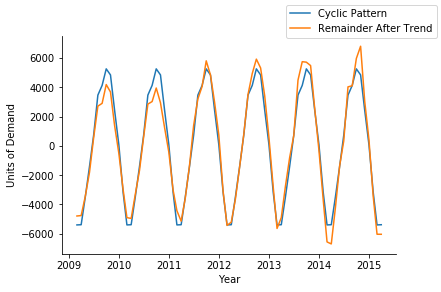

```python
cycleLen = period   # see prior cell for computation of cyclicality period
numCycles = int(len(df)/cycleLen + 0.5)
df['C'] = np.NaN   # Creates an empty column for the cyclicality component data
for i in range(len(df)):
    df.loc[df.index[i], 'C'] = avg[i % cycleLen] # Write appropriate cyclicality value

fig,ax = plt.subplots()
ax.plot(df['C'],label='Cyclic Pattern')
ax.plot(df['R1'],label='Remainder After Trend')
ax.set_xlabel('Year')
ax.set_ylabel('Units of Demand')
ax.spines['right'].set_visible(False)
ax.spines['top'].set_visible(False)
fig.legend()
```

```
Average Error:  0.023659063700256312
            Month Month-Year  Total Construction  Private Construction  \
2009-02-28     37     Jan-05               71474                 57094
2009-03-31     38     Feb-05               72048                 57531
2009-04-30     39     Mar-05               81345                 65425
2009-05-31     40     Apr-05               85485                 67829
2009-06-30     41     May-05               92959                 72862
2009-07-31     42     Jun-05               99632                 77258
2009-08-31     43     Jul-05              103158                 80480
2009-09-30     44     Aug-05              106706                 82629
2009-10-31     45     Sep-05              103269                 79584
2009-11-30     46     Oct-05              102339                 80820
2009-12-31     47     Nov-05               97549                 77774
2010-01-31     48     Dec-05               88172                 70692
2010-02-28     49     Jan-06               81058                 65339
2010-03-31     50     Feb-06               81478                 65622
2010-04-30     51     Mar-06               92855                 75163
2010-05-31     52     Apr-06               95324                 75780
2010-06-30     53     May-06              102495                 80488
2010-07-31     54     Jun-06              107607                 83196
2010-08-31     55     Jul-06              108423                 83700
2010-09-30     56     Aug-06              110434                 84649
2010-10-31     57     Sep-06              104191                 79268
2010-11-30     58     Oct-06              101582                 78199
2010-12-31     59     Nov-06               95339                 73461
2011-01-31     60     Dec-06               86436                 66972
2011-02-28     61     Jan-07               79406                 61161
2011-03-31     62     Feb-07               79177                 61437
2011-04-30     63     Mar-07               88905                 69403
2011-05-31     64     Apr-07               93375                 71433
2011-06-30     65     May-07              100534                 75685
2011-07-31     66     Jun-07              105399                 78562
...           ...        ...                 ...                   ...
2012-10-31     81     Sep-08               96755                 66012
2012-11-30     82     Oct-08               95612                 66730
2012-12-31     83     Nov-08               86067                 59993
2013-01-31     84     Dec-08               76645                 53884
2013-02-28     85     Jan-09               66944                 46974
2013-03-31     86     Feb-09               66296                 45548
2013-04-30     87     Mar-09               71624                 48688
```

[output cut: 199 more lines]

```
2014-03-31 -1310.271825       0.069978
2014-04-30  -731.291667       0.034596
2014-05-31    35.893519       0.001500
2014-06-30  -387.134259       0.015142
2014-07-31   563.307870       0.019289
2014-08-31   -25.321759       0.000866
2014-09-30   709.909722       0.022877
2014-10-31  1957.303241       0.061578
2014-11-30   610.182870       0.021846
2014-12-31   338.789352       0.013436
2015-01-31  -280.907407       0.013204
2015-02-28  -636.242063       0.034247
2015-03-31  -652.244048       0.035304

[74 rows x 14 columns]
```

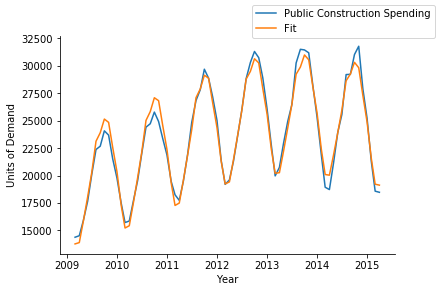

```python
df['R2Public'] = df['R1'] - df['C']
df['R2ErrorPublic'] = abs(df['R2Public']/df['Public Construction'])
df['fit'] = df['MovAvg'] + df['C']
df.drop(['sqErr'],axis=1,inplace=True)
print('Average Error: ', sum(df['R2ErrorPublic'])/len(df))
print(df)
fig,ax = plt.subplots()
ax.plot(df['Public Construction'],label='Public Construction Spending')
ax.plot(df['fit'], label = 'Fit')
ax.set_xlabel('Year')
ax.set_ylabel('Units of Demand')
ax.spines['right'].set_visible(False)
ax.spines['top'].set_visible(False)
fig.legend()
```